# Atlantic Hurricane Activity: Extended R Analysis

Jeana Song

## 1 Research questions and data

This project extends DATASCI 306 Homework 5 by asking how hurricane activity varies **by year, season, intensity, and location**, and by comparing several statistical approaches to wind speed and central pressure. The `storms.csv` file contains repeated time-stamped observations; treating them as separate independent storms would inflate counts and overstate precision.

```r
# Reproduce all calculations and save the six figures.
source("hurricane_analysis.R", local = knitr::knit_global())
```

## 2 Data validation and missingness

```r
print(dim(storms))
```

```
## [1] 19537    13
```

```r
print(missing_counts)
```

```
## # A tibble: 3 × 2
##   variable                     n_missing
##   <chr>                            <int>
## 1 category                         14734
## 2 tropicalstorm_force_diameter      9512
## 3 hurricane_force_diameter          9512
```

The category variable is naturally missing in many records of non-hurricane systems; the wind and pressure fields used here do not require imputation. We distinguish **655 storm-year groups** from **319 storms observed at hurricane strength**.

## 3 Annual hurricane counts

The custom `annual_hurricane_counts()` function counts each distinct `(year, name)` pair only once, even if the same storm has dozens of measurements.

```r
print(head(yearly))
```

```
## # A tibble: 6 × 3
##    year hurricanes category5
##   <dbl>      <int>     <int>
## 1  1975          6         0
## 2  1976          6         0
## 3  1977          5         1
## 4  1978          5         0
## 5  1979          5         1
## 6  1980          9         1
```

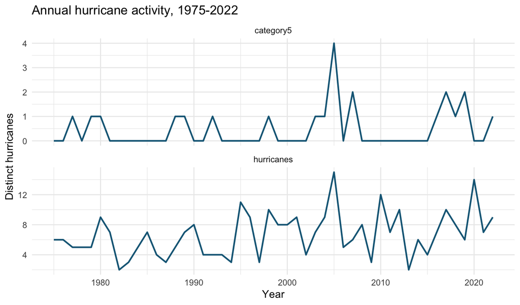

```r
print(p1)
```

## 4 Seasonality: month of first hurricane classification

This counts each hurricane in the **first month it was observed with hurricane status**; it is not the same as storm genesis or the number of recorded observations per month.

```r
print(monthly_hurricanes)
```

```
## # A tibble: 12 × 2
##    month hurricanes
##    <dbl>      <int>
##  1     1          1
##  2     2          0
##  3     3          0
##  4     4          0
##  5     5          0
##  6     6          5
##  7     7         23
##  8     8         81
##  9     9        127
## 10    10         55
## 11    11         25
## 12    12          2
```

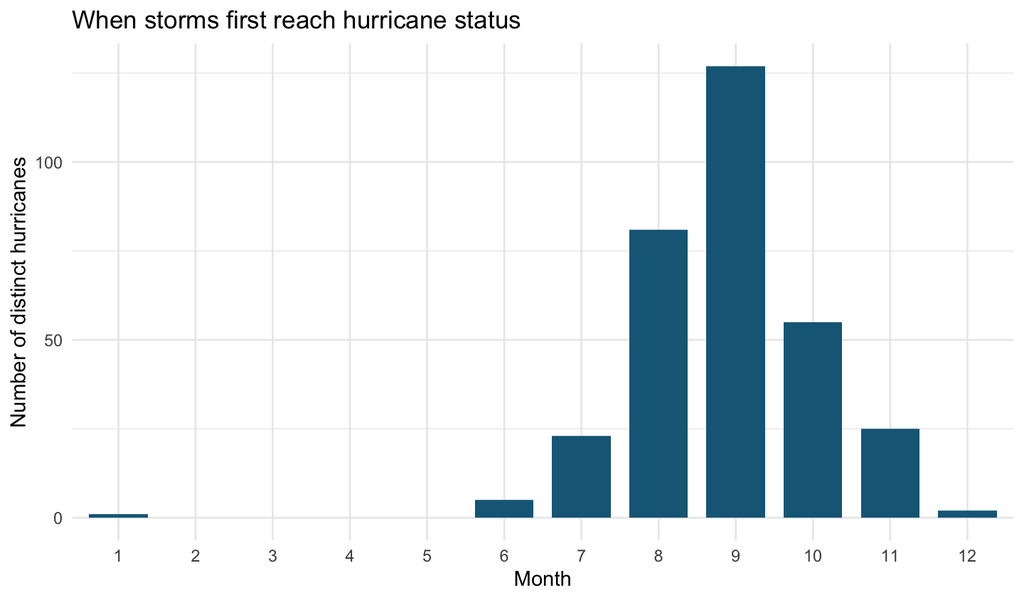

```r
print(p3)
```

## 5 Annual intensity changes

We select one peak-wind hurricane-stage record per named storm and summarize its wind speed by year. The fitted trend is descriptive: observation changes and natural variability prevent a simple climate-causation interpretation.

```r
print(head(annual_intensity))
```

```
## # A tibble: 6 × 4
##    year median_peak_wind hurricane_count major_hurricanes
##   <dbl>            <dbl>           <int>            <int>
## 1  1975             97.5               6                3
## 2  1976             90                 6                2
## 3  1977             70                 5                1
## 4  1978             85                 5                2
## 5  1979             85                 5                2
## 6  1980             85                 9                2
```

```r
print(coef(summary(intensity_trend)))
```

```
##                 Estimate Std. Error   t value   Pr(>|t|)
## (Intercept) -403.6439336 265.459190 -1.520550 0.13521744
## year           0.2468248   0.132826  1.858256 0.06953875
```

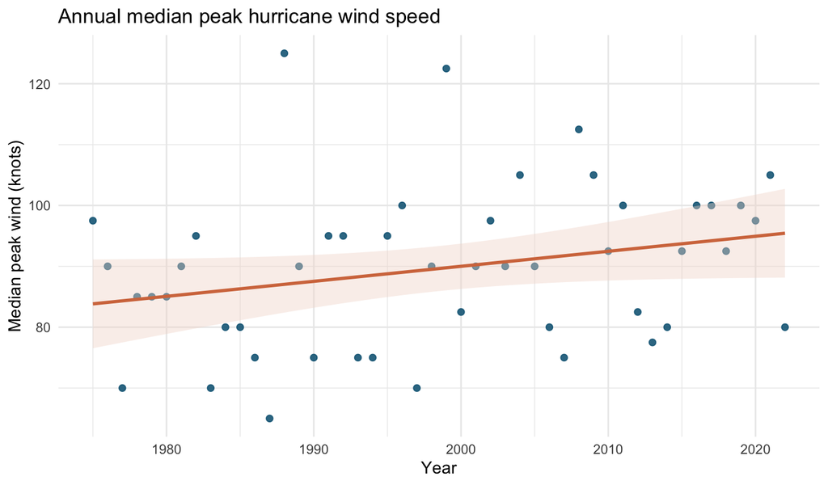

```r
print(p4)
```

## 6 Wind versus pressure: Pearson, Spearman, OLS

The first two correlations assess different patterns. **Pearson** measures linear association; **Spearman** measures monotonic rank association. The fitted ordinary least-squares regression summarizes the average change in pressure with wind speed, without claiming a causal relationship.

```r
cat("Pearson r:", unname(pearson_result$estimate), "\n")
```

```
## Pearson r: -0.9633473
```

```r
cat("Spearman rho:", unname(spearman_result$estimate), "\n")
```

```
## Spearman rho: -0.9533502
```

```r
print(coef(summary(pressure_model)))
```

```
##                Estimate  Std. Error    t value Pr(>|t|)
## (Intercept) 1036.730409 0.635421914 1631.56225        0
## wind          -0.764439 0.008330188  -91.76731        0
```

```r
cat("R squared:", summary(pressure_model)$r.squared, "\n")
```

```
## R squared: 0.928038
```

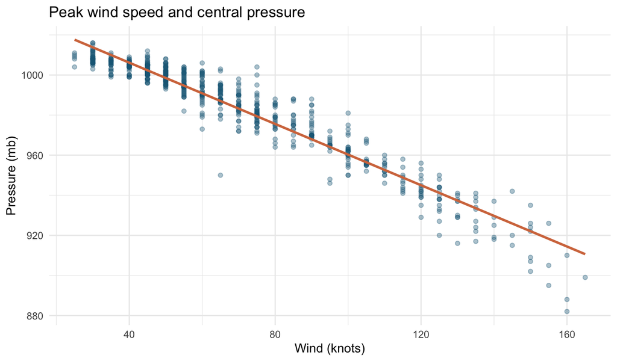

```r
print(p2)
```

## 7 Chi-squared test on quantile groups

The `to_tercile()` function creates wind and pressure classes from their 1/3 and 2/3 quantiles, then a chi-squared test examines their association. The variables were originally continuous; this grouping sacrifices information and is presented as a complementary exercise, not a replacement for correlation/regression.

```r
print(frequency)
```

```
##           pressure_group
## wind_group Low Medium High
##     Low      0     62  182
##     Medium  33    149   20
##     High   194     15    0
```

```r
print(chi)
```

```
##
##  Pearson's Chi-squared test
##
## data:  frequency
## X-squared = 694.09, df = 4, p-value < 2.2e-16
```

```r
cat("Minimum expected cell count:", min(chi$expected), "\n")
```

```
## Minimum expected cell count: 62.29618
```

## 8 Category comparison and geographic patterns

We compare **pressure across hurricane wind-based categories**, rather than treating category and wind speed as independent characteristics. The spatial display uses **one peak-intensity location per hurricane** rather than all observations, which would overrepresent longer-lived storms.

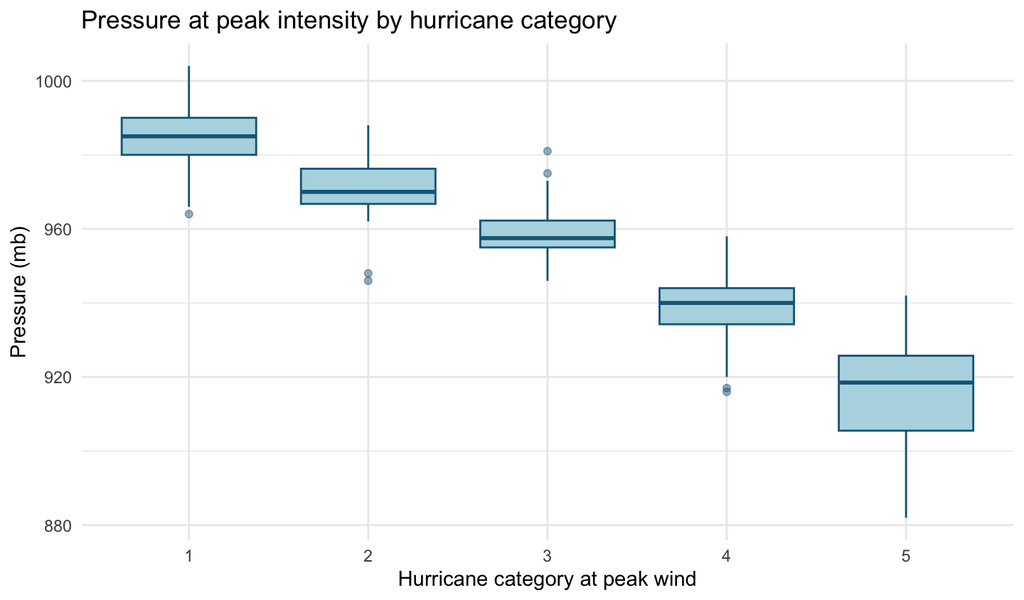

```r
print(p5)
```

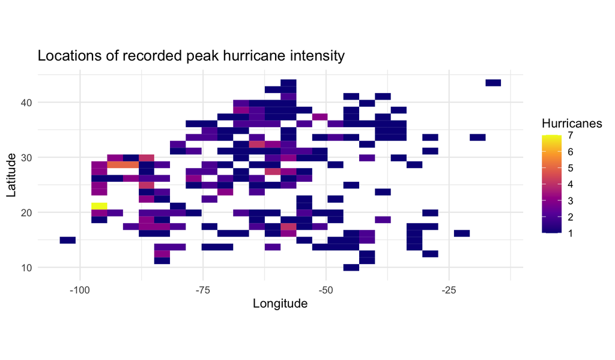

```r
print(p6)
```

## 9 Interpretation and limitations

- Seasonal counts represent the first **hurricane-status** month, not the formation month.
- Data points in wind-pressure analysis represent distinct `(year, name)` pairs, using a maximum-wind record; the choice of record affects the estimates.
- The OLS model is descriptive, not causal; linear-model assumptions should be checked before using it for formal prediction.
- Changes in detection/reporting practices and large year-to-year variability complicate long-run trend claims.
- Coordinates mark locations at peak recorded intensity, not hurricane origin or landfall.

**Data source:** `storms.csv` from the `dplyr` v1.1.4 data repository. **Provenance:** Adapted and extended from DATASCI 306 HW5.